# Ford GoBike System Data

## Preliminary Wrangling

Bike-sharing is gaining popularity, since it provides a convenient solution for short distance transportation, especially where the typical public transportation systems could not cover thoroughly. Riders can pick up a bike from one station and drop off at any other in the network. In return the system can keep on operating with income from: 1. rider membership fee, or 2. one time pay-to-ride rental fee.

This document explores a dataset containing information about individual rides of Ford GoBike sharing system covering the greater San Francisco Bay area.

```python
# import all packages and set plots to be embedded inline
import numpy as np
import pandas as pd
import matplotlib.pyplot as plt
import seaborn as sb
import glob

%matplotlib inline
```

## Gathering

The data can be directly downloaded from [Ford GoBike](https://www.fordgobike.com/system-data). Data for 2017 is packed up in one CSV file, and for 2018 there are seperate files of each month from Jan. to Nov. I want to take a look of the latest data over a whole year, namely from Dec. 2017 to Nov. 2018, therefore, it requires some data wrangling to get one complete dataset.

```python
# load in the data from 2017 into one dataframe
path = 'dataset/fordgobike/2017-fordgobike-tripdata.csv'
fgb17 = pd.read_csv(path, parse_dates=True)
# overview of data shape and composition
print(fgb17.shape)
print(fgb17.dtypes)
```

```
(519700, 15)
duration_sec                 int64
start_time                  object
end_time                    object
start_station_id             int64
start_station_name          object
start_station_latitude     float64
start_station_longitude    float64
end_station_id               int64
end_station_name            object
end_station_latitude       float64
end_station_longitude      float64
bike_id                      int64
user_type                   object
member_birth_year          float64
member_gender               object
dtype: object
```

```python
# sort out the file paths of all 11 months in 2018
file_paths = []
for file_path in glob.glob('dataset/fordgobike/2018*'):
    file_paths.append(file_path)
file_paths = sorted(file_paths)
```

```python
# load the data from 2018 into one dataframe
fgb18 = pd.DataFrame()
for file_path in file_paths:
    df = pd.read_csv(file_path, parse_dates=True)
    fgb18 = fgb18.append(df, ignore_index=True)
# overview of data shape and composition
print(fgb18.shape)
print(fgb18.dtypes)
```

```
(1732358, 16)
duration_sec                 int64
start_time                  object
end_time                    object
start_station_id           float64
start_station_name          object
start_station_latitude     float64
start_station_longitude    float64
end_station_id             float64
end_station_name            object
end_station_latitude       float64
end_station_longitude      float64
bike_id                      int64
user_type                   object
member_birth_year          float64
member_gender               object
bike_share_for_all_trip     object
dtype: object
```

```python
# create a new dataframe to save the data from 2017.12 to 2018.11
# extract the data from Dec. 2017 out of fgb17
fgb_df = fgb17[fgb17.start_time >= '2017-12-01']
```

```python
# there are 16 columns instead of 15 in fgb18, drop the additional one column
fgb18.drop(labels='bike_share_for_all_trip', axis=1, inplace=True)
#fgb18.sort_values(by='start_time', axis=0, ascending=True, inplace=True)
```

```python
# update the new dataframe by adding the data from 2018
fgb_df = fgb_df.append(fgb18, ignore_index=True)
```

```python
# high-level overview of data shape
print(fgb_df.shape)
```

```
(1818897, 15)
```

```python
fgb_df.info()
```

```
<class 'pandas.core.frame.DataFrame'>
RangeIndex: 1818897 entries, 0 to 1818896
Data columns (total 15 columns):
duration_sec               int64
start_time                 object
end_time                   object
start_station_id           float64
start_station_name         object
start_station_latitude     float64
start_station_longitude    float64
end_station_id             float64
end_station_name           object
end_station_latitude       float64
end_station_longitude      float64
bike_id                    int64
user_type                  object
member_birth_year          float64
member_gender              object
dtypes: float64(7), int64(2), object(6)
memory usage: 208.2+ MB
```

### Assessing

- data type of **start/end_station_id** and **bike_id** should be string instead of float or int
- data type of **memeber_birth_year** should be int instead of float
- data type of **start/end_time** should be converted to date-time
- data type of **user_type, member_gender** should be categorical
- missing data in **member_birth_year, member_gender**
- erroneous data in **member_birth_year**

### Cleaning

First make a copy of the original DataFrame, then conduct the cleaning process.

```python
fgb_df_clean = fgb_df.copy()
```

```python
sum(fgb_df_clean.isnull().values)
```

```
array([     0,      0,      0,  11579,  11579,      0,      0,  11579,
        11579,      0,      0,      0,      0, 114010, 113639])
```

```python
# check if there are duplicated data points
sum(fgb_df_clean.duplicated())
```

```
0
```

```python
# sort the dataframe by start time
fgb_df_clean.sort_values(['start_time'], ascending=True, inplace=True)
# reset the dataframe index
fgb_df_clean.reset_index(inplace=True, drop=True)
```

```python
def convert_data_type(dataframe, col, datatype):
    mask = dataframe[col].notnull()
    if datatype == 'str':
        dataframe.loc[mask, col] = dataframe.loc[mask, col].astype('int').astype('str')
    if datatype == 'int':
        dataframe.loc[mask, col] = dataframe.loc[mask, col].astype('int')
```

```python
# convert the type of ID-related data to strings
convert_data_type(fgb_df_clean,'start_station_id', 'str')
convert_data_type(fgb_df_clean,'end_station_id', 'str')
convert_data_type(fgb_df_clean,'bike_id', 'str')
```

```python
# convert the time-related data to datetime format
fgb_df_clean['start_time'] = pd.to_datetime(fgb_df_clean['start_time'])
fgb_df_clean['end_time'] = pd.to_datetime(fgb_df_clean['end_time'])
```

```python
# convert the user_type and member_gender to categorical data
fgb_df_clean['user_type'] = fgb_df_clean['user_type'].astype('category')
fgb_df_clean['member_gender'] = fgb_df_clean['member_gender'].astype('category')
```

```python
# convert the data type of member birth year to int
fgb_df_clean['member_birth_year'] = fgb_df_clean['member_birth_year'].fillna(0).astype(int)
```

```python
# create a new column of member age from member birth year
# filter out incorrect data
fgb_df_clean['member_age'] = 2018 - fgb_df_clean['member_birth_year']
fgb_df_clean.member_age.replace(2018, np.NaN, inplace=True)
fgb_df_clean = fgb_df_clean[fgb_df_clean.member_age < 80]
```

Check if there are inconsistent data regarding station names and station IDs.

```python
fgb17.start_station_name.nunique(), fgb17.start_station_id.nunique()
```

```
(272, 272)
```

```python
fgb18.start_station_name.nunique(), fgb18.start_station_id.nunique()
```

```
(346, 330)
```

```python
stations = fgb18.loc[:,['start_station_name','start_station_id']]
```

```python
stations.drop_duplicates(inplace=True)
```

```python
ids = stations[stations.start_station_id.duplicated()].start_station_id.values
```

```python
stations[stations.start_station_id.isin(ids)]
```

|  | start_station_name | start_station_id |
| --- | --- | --- |
| 123 | San Fernando at 7th St | 280.0 |
| 144 | 5th at Folsom | 321.0 |
| 350 | 12th St at 6th Ave | 221.0 |
| 380 | Fruitvale Ave at International Blvd | 234.0 |
| 985 | San Bruno Ave at 16th St | 101.0 |
| 1032 | 9th St at San Fernando | 281.0 |
| 1264 | S. 4th St at San Carlos St | 208.0 |
| 1942 | Mosswood Park | 212.0 |
| 2055 | 12th St at 4th Ave | 233.0 |
| 2149 | Shafter Ave at Cavour St | 205.0 |
| 2913 | Shattuck Ave at 55th Ave | 173.0 |
| 4221 | 37th St at West St | 192.0 |
| 623820 | Shattuck Ave at 55th St | 173.0 |
| 820157 | Miles Ave at Cavour St (Temporary Location) | 205.0 |
| 1018463 | MLK Jr Way at 36th St (Temporary Location) | 192.0 |
| 1018594 | 6th St at San Fernando St (Temporary Location) | 280.0 |
| 1018635 | 5th St at Folsom | 321.0 |
| 1018795 | William St at 4th St (Temporary Location) | 208.0 |
| 1019074 | Potrero Ave at 15th St (Temporary Location) | 101.0 |
| 1019280 | E 12th St at 6th Ave | 221.0 |
| 1019513 | E 12th St at 4th Ave | 233.0 |
| 1210726 | Miles Ave at Cavour St | 205.0 |
| 1211135 | 9th St at San Fernando St | 281.0 |
| 1211845 | Webster St at MacArthur Blvd (Temporary Location) | 212.0 |
| 1212447 | 4th Ave at E 12th St (Temporary Location) | 233.0 |
| 1213069 | 6th Ave at E 12th St (Temporary Location) | 221.0 |
| 1214364 | Lane St at Van Dyke Ave | 358.0 |
| 1611496 | Williams Ave at 3rd St | 358.0 |
| 1629903 | Farnam St at Fruitvale Ave | 234.0 |

```python
fgb_df_clean.end_station_name.nunique(), fgb_df_clean.end_station_id.nunique()
```

```
(346, 330)
```

```python
fgb_df_clean.bike_id.nunique()
```

```
4087
```

```python
fgb_df_clean['duration_sec'].mean(), fgb_df_clean['duration_sec'].mean()/60
```

```
(780.4081028010429, 13.006801713350715)
```

### What is the structure of your dataset?

There are 181,8897 trips recorded for the last one year from 2017.12 to 2018.11. The data consists of 15 columns covering various details from trip duration, start/end time, start/end station name and GPS location, to user information for each trip:

1. trip: duration, time stamp, start/end location
2. user: age, gender, type
3. station: geographical distribution, traffics

Among those, duration is numeric, station- and user-related data are mostly categorical.

### What is/are the main feature(s) of interest in your dataset?

In this project, I want to know about user demand for this bike sharing system, by focusing on:

1. user behavior: duration, time stamps -> time-related patterns
2. station activity: routes, pick-ups (outflow), drop-offs (inflow) -> geographical concentration, tidal traffic pattern

The key to interpret the data is to calculate trip counts regarding the two aspects above.

### What features in the dataset do you think will help support your investigation into your feature(s) of interest?

I think the user demands during weekday and weekend are different, so I need to take a look at the time stamp and divide the trips into different groups. Moreover, this step is also necessary when examing the station traffics to look for tidal traffic patterns.

## Univariate Exploration

I will start with checking the distribution of trip durations.

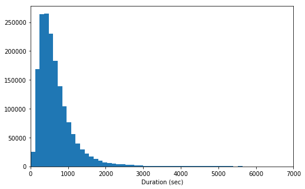

```python
# start with a standard-scaled plot
binsize = 60*2
bins = np.arange(0, fgb_df_clean['duration_sec'].max()+binsize, binsize)

plt.figure(figsize=[8, 5])
plt.hist(data = fgb_df_clean, x = 'duration_sec', bins = bins)
plt.xlabel('Duration (sec)')
plt.xlim(0,7000)
plt.show()
```

The distribution is strongly right skewed. So I will check the distribution again but on a log scale.

```python
np.log10(fgb_df_clean['duration_sec']).describe()
```

```
count    1.702473e+06
mean     2.737400e+00
std      3.117594e-01
min      1.785330e+00
25%      2.539076e+00
50%      2.735599e+00
75%      2.924796e+00
max      4.935915e+00
Name: duration_sec, dtype: float64
```

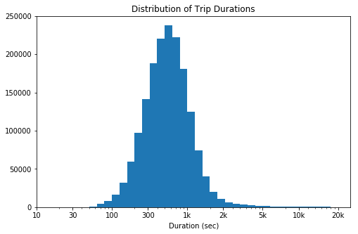

```python
log_binsize = 0.1
bins = 10 ** np.arange(1.7, np.log10(fgb_df_clean['duration_sec'].max())+log_binsize, log_binsize)

plt.figure(figsize=[8, 5])
plt.hist(data = fgb_df_clean, x = 'duration_sec', bins = bins)
plt.xscale('log')
plt.xticks([10, 30, 100, 300, 1e3, 3e3, 1e4, 3e4, 1e5], [10, 30, 100, 300, '1k', '2k', '5k', '10k', '20k'])
plt.xlabel('Duration (sec)')
plt.title('Distribution of Trip Durations')
plt.show()
```

When plotted on a log-scale, the duration distribution now seems normal with one peak between 500 and 600 seconds.

Next check out the station traffics, the top 20 stations with most pick-ups and drop-offs will be plotted with horizontal bar charts.

```python
# check out the top 20 start/end stations
start_stations = fgb_df_clean.start_station_name.value_counts().nlargest(20)
end_stations = fgb_df_clean.end_station_name.value_counts().nlargest(20)
```

```python
# check if the 20 most popular stations overlap each other regardless of in- or outflow
sum(start_stations.index.isin(end_stations.index))
```

```
19
```

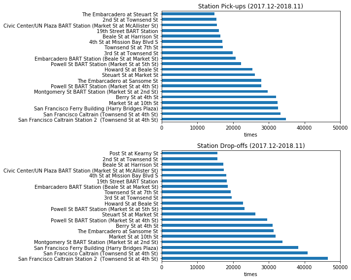

```python
fig, ax = plt.subplots(nrows=2, figsize = [10,8])
default_color = sb.color_palette()[0]

plt.subplot(2,1,1)
start_stations.plot.barh(color=default_color);
plt.title('Station Pick-ups (2017.12-2018.11)')
plt.xlabel('times')
plt.xlim(0, 50000)

plt.subplot(2,1,2)
end_stations.plot.barh(color=default_color);
plt.title('Station Drop-offs (2017.12-2018.11)')
plt.xlabel('times')
plt.xlim(0, 50000)
plt.tight_layout()
```

Roughly sorting through the results, most of stations are both with greater numbers of pick-ups and drop-offs, but don't balance out. For example, more than 45,000 rides stopped at San Francisco Caltrain Station 2 but only about 35,000 started from there. I will exam the data in the next section by implementing [Tufte's slopegraph](http://charliepark.org/slopegraphs/), which can help me compare the number of pick-ups and drop-offs at each station in a better way.

Now take a look at one of the parameters in user demographics: age.

- Member age

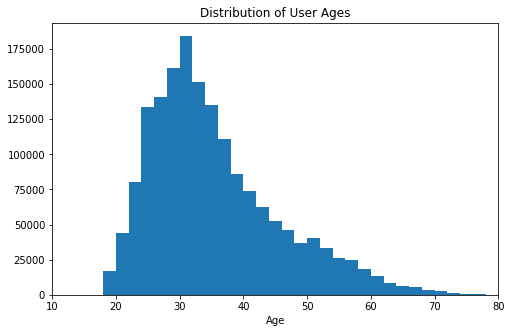

```python
binsize = 2
bins = np.arange(0, fgb_df_clean['member_age'].max()+binsize, binsize)

plt.figure(figsize=[8, 5])
plt.hist(data = fgb_df_clean, x = 'member_age', bins = bins);
plt.xlim(10, 80)
plt.xlabel('Age');
plt.title('Distribution of User Ages');
```

The distribution of member age is slightly right skewed, with the peak value around 30.

### Discuss the distribution(s) of your variable(s) of interest. Were there any unusual points? Did you need to perform any transformations?

The distribution of trip duration covers a wide range, so I took a look at the data using logarithmic transformation, in this way, the distribution looks normal instead of right skewed. As for user age, the distribution is right skewed, the majority is under 60 years old.

### Of the features you investigated, were there any unusual distributions? Did you perform any operations on the data to tidy, adjust, or change the form of the data? If so, why did you do this?

To check the distribution of user age, it is necessary to slightly change the data by converting the birth year to actual age. One thing that caught my eye is the number of pick-ups and drop-offs at the busiest stations, since the numbers for the same station cannot cancel each other out, I would like to investigate this later by introducing more variables.

## Bivariate Exploration

In this section, I would like to take on the following questions:

1. When are most trips taken in terms of time of day, day of the week, or month of the year?
2. How long on average does one trip take in terms of time of day, day of the week, or month of the year?
3. How does the trip count vary with different user groups?
4. How does the inflow (# of drop-offs) and outflow (# of pick-ups) at the most popular stations differentiate?

**Q1&2**: To answer these questions, I need to first extract the key features about time of day (hour), day of week, month out of column start_time or end_time.

```python
# create year_month/month/day of week/hour columns
fgb_df_clean['year_month'] = fgb_df_clean['start_time'].map(lambda x: 100*x.year + x.month)
fgb_df_clean['month'] = fgb_df_clean['start_time'].map(lambda x: x.month)
fgb_df_clean['day_of_week'] = fgb_df_clean['start_time'].dt.day_name()
fgb_df_clean['hour'] = fgb_df_clean['start_time'].map(lambda x: x.hour)
```

```python
fgb_df_clean['date'] = fgb_df_clean['start_time'].map(lambda x: str(x.year) + '-' + str(x.month) + '-' + str(x.day))
```

```python
# convert day_of_week into ordered categorical types
ordinal_var_dict = {'day_of_week': ['Monday','Tuesday','Wednesday','Thursday','Friday','Saturday','Sunday']}

for var in ordinal_var_dict:
    ordered_var = pd.api.types.CategoricalDtype(ordered = True,
                                                categories = ordinal_var_dict[var])
    fgb_df_clean[var] = fgb_df_clean[var].astype(ordered_var)
```

```python
def agg_plot(df, cat_var, num_var):
    """Plot the aggregated values of interest by certain time base"""
    base_color = sb.color_palette()[0]
    fig, ax = plt.subplots(1, 2, figsize = [16,4])
    agg_val0 = df.groupby(cat_var).size()
    agg_val0 = agg_val0.reset_index(name = 'trip_count')
    agg_val1 = df.groupby(cat_var)

    g1 = sb.barplot(data=agg_val0, x=cat_var, y='trip_count', color=base_color, ax=ax[0])
    ax[0].set_ylabel('trip count')
    ticks0 = np.arange(0,350000,50000)
    labels0 = [0, '50k', '100k', '150k', '200k', '250k', '300k']
    ax[0].set_yticks(ticks0)
    ax[0].set_yticklabels(labels0)

    g2 = sb.boxplot(data=df, x=cat_var, y=num_var, color=base_color)
    ax[1].set_yscale('log')
    ax[1].set_ylabel('duration')
    ax[1].set_yticklabels([])
#    ticks1 = [300, 600, 900, 1200]
#    labels1 = ['5min', '10min', '15min', '20min']
#    ax[1].set_yticks(ticks1)
#    ax[1].set_yticklabels(labels1)
    ax[1].set_ylim(300,1200)

    if cat_var != 'day_of_week':
        if cat_var == 'year_month':
            locs, labels = plt.xticks()
            ticks = locs
            labels = ['Dec','Jan','Feb','Mar','Apr','May','Jun','Jul','Aug','Sep','Oct','Nov']
            ax[0].axvline([0.5], ls='--', color='r')
            ax[1].axvline([0.5], ls='--', color='r')
        if cat_var == 'hour':
            hours = np.arange(0,24,1)
            ticks = hours
            labels = ['{}'.format(hr) for hr in ticks]
        for i in range(2):
                ax[i].set_xticks(ticks)
                ax[i].set_xticklabels(labels)
```

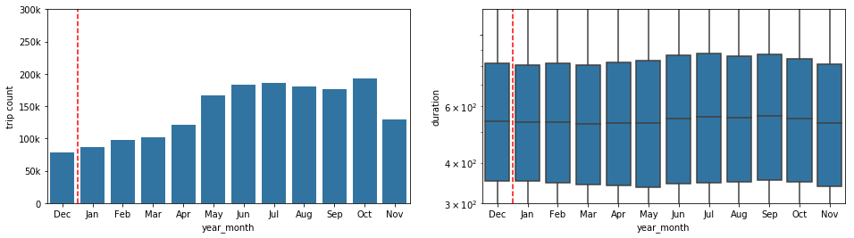

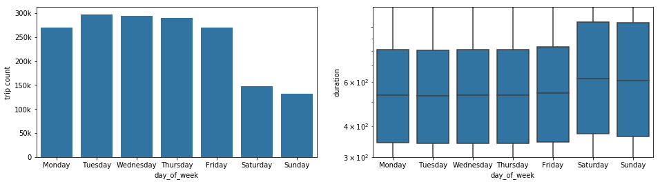

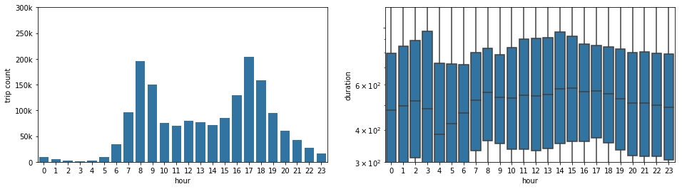

```python
# plot the trip counts and mean duration per trip by month/day of week/hour respectively
agg_plot(fgb_df_clean, 'year_month', 'duration_sec')
agg_plot(fgb_df_clean, 'day_of_week', 'duration_sec')
agg_plot(fgb_df_clean, 'hour', 'duration_sec')
```

- The monthly results indicate a seasonal alternation period that less trips are made from January to April than from May to October, which then followed by a decrease in November (expected to be the same also in Decemeber). This is not surprising.
- The weekly results indicate that more trips are taken during weekdays, but shorter on average comparing to weekends, maybe due to different usages. During weekdays, people may take more short trips for commutes, however during weekends more longer trips for sightseeing, shopping etc.
- The hourly result shows two peaks: one around 8 a.m. and one around 17 p.m., both are typical rush hours for morning/night commutes.

**Q3**: Now take a look at the relation between user groups and trip counts. Since there are no user id documented, we don't distinguish between users for trips, therefore bar chart can be used to describe the relationships betwen the two variables: user features and trip count.

1. member gender

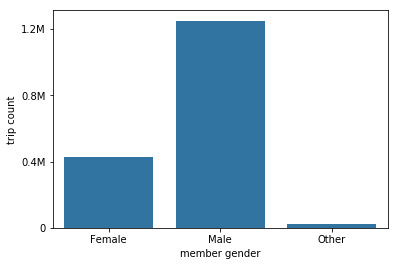

```python
default_color = sb.color_palette()[0]
sb.countplot(data = fgb_df_clean, x = 'member_gender', color = default_color);
plt.xlabel('member gender');
plt.ylabel('trip count');
plt.yticks([0, 400000, 800000, 1200000], [0, '0.4M', '0.8M', '1.2M']);
```

Most of the trips are taken by male users.

1. subscription status (user_type): subscriber or customer

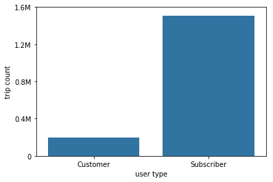

```python
default_color = sb.color_palette()[0]
sb.countplot(data = fgb_df_clean, x = 'user_type', color = default_color);
plt.xlabel('user type');
plt.ylabel('trip count');
plt.yticks([0, 400000, 800000, 1200000, 1600000], [0, '0.4M', '0.8M', '1.2M', '1.6M']);
```

Most of the trips are taken by subscriber. To further investigate how many among subscriber are female or male, it requires to introduce more variables.

**Q4**: To investigate how station traffic inflow and outflow differentiate, I will have to change the form of data by creating a new dataframe, with summarized pick-up and drop-off numbers, and set the order as descending for the convenience of analysis.

step 1: extract the information of stations (ID, name, GPS location) and save as a new dataframe **stations_df**.

```python
stations_df = fgb_df_clean.loc[:,['start_station_name','start_station_id','start_station_latitude','start_station_longitude']]
stations_df.drop_duplicates(inplace=True)
stations_df.dropna(axis=0, inplace=True)
stations_df.reset_index(inplace=True, drop=True)
stations_df.rename(lambda x: x.replace('start_', ''), axis='columns', inplace=True)
```

```python
# due slightly difference in the GPS locations some of the duplicated data are not cleaned above
idx = stations_df[stations_df.station_name.duplicated()].index
stations_df.drop(labels=idx, axis=0, inplace=True)
```

```python
stations_df.info()
```

```
<class 'pandas.core.frame.DataFrame'>
Int64Index: 346 entries, 0 to 354
Data columns (total 4 columns):
station_name         346 non-null object
station_id           346 non-null object
station_latitude     346 non-null float64
station_longitude    346 non-null float64
dtypes: float64(2), object(2)
memory usage: 13.5+ KB
```

step 2: summarize station traffics (station inflow/drop-offs -> stin, station outflow/pick-ups -> stout)

```python
# aggregate and transform the data of stations setting as start location
# trip counts start from each station is renamed as outflow
stout = fgb_df_clean.groupby(['start_station_name']).size()
stout = stout.reset_index(name='outflow')
stout.rename(lambda x: x.replace('start_', ''), axis='columns', inplace=True)
```

```python
# aggregate and transform the data of stations setting as end location
# trip counts start from each station is renamed as inflow
stin = fgb_df_clean.groupby(['end_station_name']).size()
stin = stin.reset_index(name='inflow')
stin.rename(lambda x: x.replace('end_', ''), axis='columns', inplace=True)
```

step 3: merge the dataframes above as one new dataframe **station_traffics** with all necessary data for analysis.

```python
station_traffics = stout.merge(stin, on='station_name', how='inner')
station_traffics = station_traffics.merge(stations_df, on='station_name', how='inner')
```

step 4: plot the inflow/drop-offs and outflow/pick-ups for the stations with the most total traffic volume (pick-ups plus drop-offs)

```python
station_traffics['total_traffic_volume'] = station_traffics['inflow'] + station_traffics['outflow']
station_traffics.head(1)
```

|  | station_name | outflow | inflow | station_id | station_latitude | station_longitude | total_traffic_volume |
| --- | --- | --- | --- | --- | --- | --- | --- |
| 0 | 10th Ave at E 15th St | 655 | 627 | 222 | 37.792714 | -122.24878 | 1282 |

```python
def slopegraph(df, num):
    """Plot the slopegraph"""
    fig, ax = plt.subplots(1, 1, figsize=(5, 14))
    # These are the colors that will be used in the plot
    color_sequence = sb.color_palette('Blues_d',num)

    # Remove the plot frame lines. They are unnecessary here.
    ax.spines['top'].set_visible(False)
    ax.spines['bottom'].set_visible(False)
    ax.spines['right'].set_visible(False)
    ax.spines['left'].set_visible(False)

    ax.get_xaxis().tick_bottom()
    ax.get_yaxis().tick_left()
    ax.get_xaxis().set_ticks([])
    ax.get_yaxis().set_ticks([])

    # Sort the dataframe with descending orders of inflow.
    ldf = df.sort_values(by='total_traffic_volume', ascending=False).loc[:num-1,:].reset_index(drop=True)
    left = 'inflow'
    right = 'outflow'
#    print(ldf.head(num))
    for i in range(num):
        line = plt.plot([0,1], [ldf.loc[i,left], ldf.loc[i,right]],
                        lw=2, color=color_sequence[i])
        y_left_pos = ldf.loc[i,left] + y_left_offset[i]
        y_right_pos = ldf.loc[i,right] + y_right_offset[i]
        plt.text(-0.15,y_left_pos, str(ldf.loc[i,left]))
        plt.text(-0.35,y_left_pos, ldf.loc[i,'station_id'])
        plt.text(1+0.03,y_right_pos, str(ldf.loc[i,right]))
        plt.text(1+0.2,y_right_pos, ldf.loc[i,'station_name'])

    plt.text(-0.18,max(ldf.loc[0,left],ldf.loc[0,right])*1.015, 'INFLOW\ndrop-offs')
    plt.text(-0.4,max(ldf.loc[0,left],ldf.loc[0,right])*1.015, 'station ID\n')
    plt.text(1,max(ldf.loc[0,left],ldf.loc[0,right])*1.015, 'OUTFLOW\n pick-ups')
    plt.text(1+0.5,max(ldf.loc[0,left],ldf.loc[0,right])*1.015, 'station name\n')
    plt.title('Total Pick-ups & Drop-offs from 2017.12 to 2018.11 \n')
```

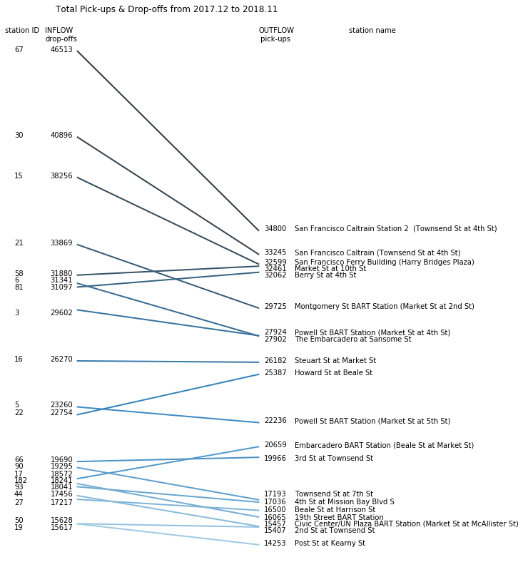

```python
#y_left_offset = [0, 0, 0, 0, 0, 0, 100, -300, 0, 0, 0, 0, 80, 120, 400, -200, -300, 0, 0, -100]
#y_right_offset = [0, 0, 0, -200, 0, 0, 0, 0, 0, 0, 0, -200, 0, -50, 450, 150, -400, -200, -150, 0]
y_left_offset = [0, 0, 0, 0, 0, -100, 100, -300, 0, 0, 0, 0, 180, 0, -100, 100, -300, 0, 100, -350]
y_right_offset = [0, 0, 0, -250, 0, -280, -320, 100, 0, 0, 0, -200, 0, 250, -100, -150, -50, 50, -350, 0]
slopegraph(station_traffics, 20)
```

So the slopegraph shows that some of the most popular stations, especially those with greatest user demands, may suffer from imbalances between pick-ups and drop-offs, which may require additional rellocations of bikes, in order to make the most use of them. This also indicates that the traffic flow has certain direction, whether it is tidal or not can only be determined by introducing time variable.

Further investigation about rellocations can be conducted by tracking the bike ID, to see if there are station jumps, meaning a bike is dropped off at one station, but in the next trip starts from a different one. This will not be conducted here in this project.

### Talk about some of the relationships you observed in this part of the investigation. How did the feature(s) of interest vary with other features in the dataset?

Q1: The bar charts of trip counts against different time measurements indicate that In total most of trips are taken during rush hours, weekdays and warm seasons. Since that rush hour commutes don't apply for weekends, I need to isolate hour and day of week next, in order to check the difference between weekdays and weekends.

Q2: The median of trip duration seems to be shorter during weekdays than weekends.

Q3: User gender and subscription status do correlate with trip counts, more trips are made by male users and subscribers respectively.

Q4: The slopegraph shows how the station traffics in total looks like, with information about the inflow (drop-offs), outflow (pick-ups), and the gap in between. It also indicates that user demand varies from station to station, and stations with the greatest user demands tend to have bigger gap between inflow and outflow, manual rellocation should be required.

### Did you observe any interesting relationships between the other features (not the main feature(s) of interest)?

There seems to be an inverse relation between trip duration and trip counts. Although there are more trips during rush hours, but the median of duration is shorter than normal daytime. When looking at the results on a weekly base, the median duration is longer on weekends than weekdays. Maybe less people tend to ride longer routes on weekends, and more users ride shorter routes during weekdays for different purposes, such as sightseeing comparing to daily commutes.

## Multivariate Exploration

In this section, I'd like to explore the following points:

1. How many trips are taken by different user groups respectively?
2. plot trip counts against two time variables in order to explore the correlation between time and trip counts a little bit further.
3. check the geographic distributions of stations along with traffic volumes.
4. take a look at the busiest station with the largest total traffic volume, plot its traffic against two time variables (hour, weekday/weekend), in search for tidal patterns of station traffic, if the flow direction is relevant to time or not.

**Q1**: How many trips are taken by different user groups respectively?

```python
trips = fgb_df_clean.groupby(['user_type','member_gender']).size()
trips = trips.reset_index(name='trip_count')
total = trips.trip_count.sum()
trips = trips.pivot('user_type','member_gender', 'trip_count')/total*100
```

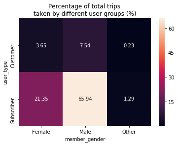

```python
sb.heatmap(trips, annot=True, fmt=".2f");
plt.title('Percentage of total trips \ntaken by different user groups (%)');
```

```python
user_stats = fgb_df_clean[fgb_df_clean.member_age < 100].groupby(['user_type','member_gender']).mean()
```

```python
user_stats
```

| user_type | member_gender | duration_sec | start_station_latitude | start_station_longitude | end_station_latitude | end_station_longitude | member_birth_year | member_age | year_month | month | hour |
| --- | --- | --- | --- | --- | --- | --- | --- | --- | --- | --- | --- |
| Customer | Female | 1835.209320 | 37.773271 | -122.353295 | 37.773694 | -122.352930 | 1986.189139 | 31.810861 | 201803.374516 | 6.753035 | 14.042983 |
|  | Male | 1528.175292 | 37.772308 | -122.361645 | 37.772487 | -122.361305 | 1984.567191 | 33.432809 | 201803.913304 | 7.015257 | 14.165370 |
|  | Other | 1561.123741 | 37.778845 | -122.349478 | 37.779542 | -122.349499 | 1983.351847 | 34.648153 | 201803.434771 | 6.741410 | 14.342547 |
| Subscriber | Female | 750.794292 | 37.772424 | -122.344949 | 37.772532 | -122.344192 | 1983.874087 | 34.125913 | 201802.555345 | 6.839739 | 13.234303 |
|  | Male | 643.821210 | 37.762991 | -122.347817 | 37.763057 | -122.347239 | 1982.411394 | 35.588606 | 201801.889711 | 6.811667 | 13.455455 |
|  | Other | 755.768572 | 37.792450 | -122.348914 | 37.792618 | -122.348555 | 1982.452067 | 35.547933 | 201802.178897 | 6.940368 | 13.824108 |

```python
fgb_df_clean[fgb_df_clean.member_age < 80].member_age.describe()
```

```
count    1.702473e+06
mean     3.497307e+01
std      1.015946e+01
min      1.800000e+01
25%      2.800000e+01
50%      3.300000e+01
75%      4.000000e+01
max      7.900000e+01
Name: member_age, dtype: float64
```

```python
fgb_df_rev = fgb_df_clean[fgb_df_clean.member_age < 80]
```

```python
fgb_df_rev.shape
```

```
(1702473, 21)
```

```python
 fgb_df_clean[fgb_df_clean.member_age > 80].shape
```

```
(0, 21)
```

```python
bin_edges = np.arange(10,90,10)
bin_idxs = pd.cut(fgb_df_rev['member_age'], bin_edges, right=False, include_lowest=True, labels=False).astype(int)
```

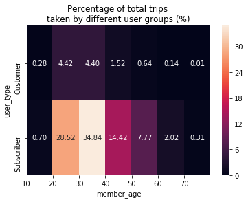

```python
df0 = fgb_df_rev.groupby([bin_idxs, 'user_type']).size()
df0 = df0.reset_index(name='trip_count')
df0 = df0.pivot('user_type','member_age', 'trip_count')/total*100
sb.heatmap(df0, annot=True, fmt=".2f");
plt.xticks([0,1,2,3,4,5,6],['10','20','30','40','50','60','70'])
#plt.gca().invert_xaxis()
plt.title('Percentage of total trips \ntaken by different user groups (%)');
```

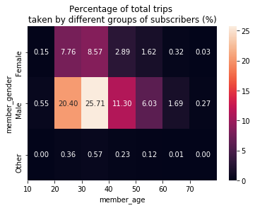

```python
df1 = fgb_df_rev.query('user_type == "Subscriber"').groupby([bin_idxs, 'member_gender']).size()
df1 = df1.reset_index(name='trip_count')
df1 = df1.pivot('member_gender', 'member_age', 'trip_count')/total*100

sb.heatmap(df1, annot=True, fmt=".2f");
plt.xticks([0,1,2,3,4,5,6],['10','20','30','40','50','60','70'])
#plt.gca().invert_yaxis()
plt.title('Percentage of total trips \ntaken by different groups of subscribers (%)');
```

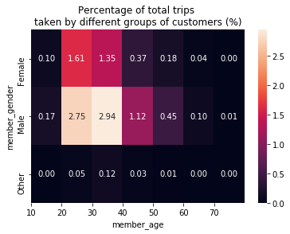

```python
df2 = fgb_df_rev.query('user_type == "Customer"').groupby([bin_idxs, 'member_gender']).size()
df2 = df2.reset_index(name='trip_count')
df2 = df2.pivot('member_gender', 'member_age', 'trip_count')/total*100

sb.heatmap(df2, annot=True, fmt=".2f");
plt.xticks([0,1,2,3,4,5,6],['10','20','30','40','50','60','70'])
#plt.gca().invert_yaxis()
plt.title('Percentage of total trips \ntaken by different groups of customers (%)');
```

**Q2**: how does the hourly trip count spread over one week?

Next, I will separate the day of week and hour for trip counts.

```python
def agg_plot_3(df0, cat_var, num_var='duration_sec', time_base='hour'):

    df1 = df0.groupby([cat_var, time_base]).size()/52
    df1 = df1.reset_index(name='mean_trip_count')

    df2 = df0.groupby([cat_var, time_base])[num_var].mean()
    df2 = df2.reset_index(name='mean_duration_sec')

    fig, ax = plt.subplots(1, 2, figsize = [14,5])
    sb.pointplot(data = df1, x = time_base, y = 'mean_trip_count', hue = cat_var,
           palette = 'Blues', linestyles = '', ax=ax[0])
    sb.pointplot(data = df2, x = time_base, y = 'mean_duration_sec', hue = cat_var,
           palette = 'Blues', linestyles = '-', ax=ax[1])
    ax[0].set_ylabel('mean trip count')
    ax[1].set_ylabel('mean trip duration (sec)')
```

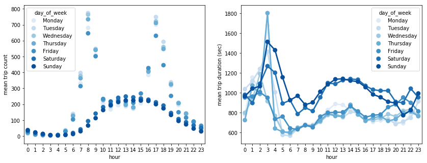

```python
agg_plot_3(fgb_df_clean, 'day_of_week')
```

Now it is clear that during weekdays, there are more trips at rush hours due to morning/night commutes, and during weekends, more at normal daytime. The average duration per trip is longer at normal daytime than rush hours, both during weekdays and weekends.

**Q3**: how does the geographical distribution of station traffic volumes look like?

I will plot each station's location with scatter plot, using the longitude and latitude as x and y values, and point size related to the total station traffic volume or popularity.

```python
def gps_plot(num_var, boundary, gain, axes):
    x1,x2 = boundary[0]
    y1,y2 = boundary[1]
    popularity = station_traffics[num_var]/gain

    axes.scatter(x='station_longitude', y='station_latitude', data=station_traffics, alpha=1/2, s=popularity);
    axes.set_xlim(x1,x2)
    axes.set_ylim(y1,y2)
    axes.set_xlabel('longitude')
    axes.set_ylabel('latitude')
    axes.grid(True, which='both')
```

```python
# San Francisco
boundary_1 = [(-122.48,-122.38+0.02),(37.72,37.84)]
# Berkeley
boundary_2 = [(-122.3-0.02,-122.2),(37.77,37.89)]
# San José
boundary_3 = [(-121.84,-121.96),(37.40,37.28)]
```

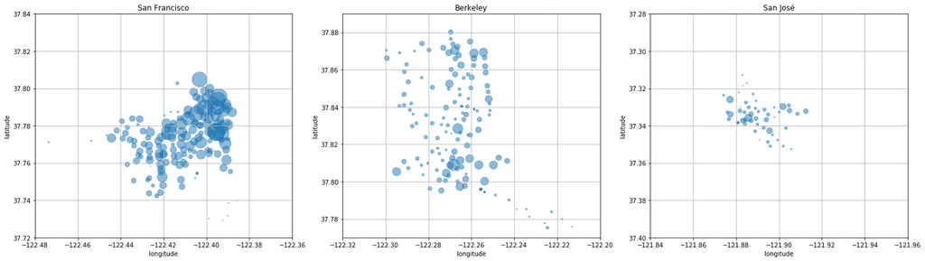

```python
fig, ax = plt.subplots(1,3,figsize=[21,6])

gps_plot('total_traffic_volume', boundary_1, 100, ax[0])
#gps_plot('outflow', boundary_1, 50, ax[1,0])
ax[0].set_title('San Francisco');

gps_plot('total_traffic_volume', boundary_2, 100, ax[1])
#gps_plot('outflow', boundary_2,50, ax[1,1])
ax[1].set_title('Berkeley');

gps_plot('total_traffic_volume', boundary_3, 100, ax[2])
#gps_plot('outflow', boundary_3,50, ax[1,2])
ax[2].set_title('San José');

plt.tight_layout()
```

I look up the GPS location, and find out that the stations are located separately in three cities: San Francisco, Berkeley and San José. I zoomed in to each district, and set the size of each point to be relevant to the traffic volume, most of the traffics are concentrated in San Francisco.

**Q4** How does station traffic change over time?

Pick out the stations with the most drop-offs plus pick-ups on weekdays and weekends, then plot the hourly average inflow and outflow, and how then change from day to day in one week.

```python
fgb_df_clean.loc[:,'weekday'] = 1
sat = fgb_df_clean['day_of_week'] == 'Saturday'
sun = fgb_df_clean['day_of_week'] == 'Sunday'
fgb_df_clean.loc[sat | sun, 'weekday'] = 0
```

Create new dataframes for the stations with most traffics, one on weekday, and one at weekends.

```python
def traffics(flag):

    mask = fgb_df_clean.weekday == flag
    days = fgb_df_clean.loc[mask,:].date.nunique()
    # aggregate and transform the data of stations setting as start location
    # trip counts start from each station is renamed as outflow
    stout = (fgb_df_clean.loc[mask,:].groupby(['start_station_name']).size()).apply(lambda x: round(x,2))
    stout = stout.reset_index(name='outflow')
    stout.rename(lambda x: x.replace('start_', ''), axis='columns', inplace=True)
    # aggregate and transform the data of stations setting as end location
    # trip counts start from each station is renamed as inflow
    stin = (fgb_df_clean.loc[mask,:].groupby(['end_station_name']).size()).apply(lambda x: round(x,2))
    stin = stin.reset_index(name='inflow')
    stin.rename(lambda x: x.replace('end_', ''), axis='columns', inplace=True)
    # merge dataframe
    traffics = stout.merge(stin, on='station_name', how='inner')
    traffics = traffics.merge(stations_df, on='station_name', how='inner')
    traffics['total_traffic_volume'] = traffics['inflow'] + traffics['outflow']

    return traffics
```

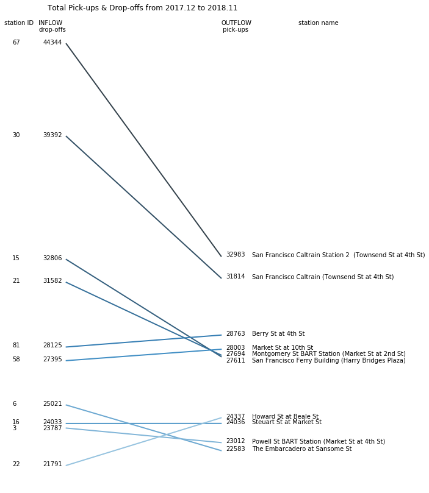

```python
n = 10
y_left_offset = [0]*n
y_right_offset = [0]*n
y_left_offset[8] = -100
y_right_offset[2] = -300
#y_right_offset = [0, 0, 0, -300, 0, 0, 125, -375, 125, -125]
weekday_traffics = traffics(1)
slopegraph(weekday_traffics, n)
```

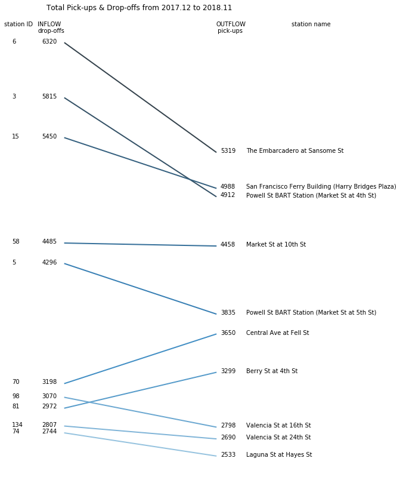

```python
n = 10
y_left_offset = [0]*n
#y_left_offset[-1] = -250
y_right_offset = [0]*n
#y_right_offset[-1] = -125
weekend_traffics = traffics(0)
slopegraph(weekend_traffics, n)
```

- The slope graphs above indicate that the traffic condition on weekdays and weekends are different.

Aggregate the data to yield the mean hourly traffic volumes.

```python
def plot_busiest_station_traffic(df, rank):
    # Sort the dataframe with descending orders of total_traffic_volume.
    traffics = df.sort_values(by='total_traffic_volume', ascending=False).loc[:19,:].reset_index(drop=True)
    stations = traffics.station_name[:19]

    station = stations[rank-1]
    weeks = 52
    df1 = fgb_df_clean[fgb_df_clean.end_station_name == station]
    df2 = fgb_df_clean[fgb_df_clean.start_station_name == station]
    dfin = (df1.groupby(['hour','day_of_week']).size()/weeks).reset_index(name='inflow')
    dfout = (df2.groupby(['hour','day_of_week']).size()/weeks).reset_index(name='outflow')

    busiest_station = dfin.merge(dfout, on=['hour', 'day_of_week'])
    busiest_station.loc[:,'outflow'] = - busiest_station.loc[:,'outflow']
    busiest_station['net_flow'] = busiest_station.loc[:,'inflow'] + busiest_station.loc[:,'outflow']
    station_traffic_stats = busiest_station.groupby('hour').agg('mean').reset_index()

    base_colors = sb.color_palette()
    plt.figure(figsize=[9,4])
    plt.subplot(2,1,1)
    g1 = sb.barplot(data=station_traffic_stats, x='hour', y='inflow', color=base_colors[0]);
    g2 = sb.barplot(data=station_traffic_stats, x='hour', y='outflow', color=base_colors[1]);
    plt.title('Traffic at {}'.format(station));
    plt.ylabel('pick-ups & drop-offs')
    plt.subplot(2,1,2)
    g3 = sb.barplot(data=station_traffic_stats, x='hour', y='net_flow', color=base_colors[2], alpha=0.7);

    plt.figure()
    g = sb.FacetGrid(data=busiest_station, row='day_of_week', height=2, aspect=4)
    base_colors = sb.color_palette()
    #plt.title('Traffic at {}'.format(station));
    g.map(sb.barplot, 'hour', 'inflow', color=base_colors[0]);
    g.map(sb.barplot, 'hour', 'outflow', color=base_colors[1]);
    g.add_legend()
    plt.ylabel('pick-ups & drop-offs')
```

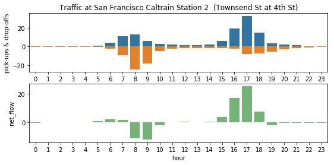

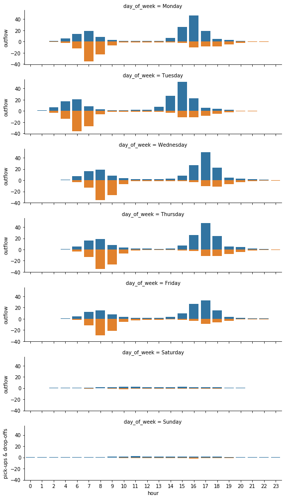

```python
plot_busiest_station_traffic(weekday_traffics, 1)
```

- On weekdays at San Francisco Caltrain Station 2, there are in total more outflow (orange) than inflow (blue) in the morning, and the opposite in the afternoon. On weekends, there are only a few pick-ups and drop-offs throughout the whole day.

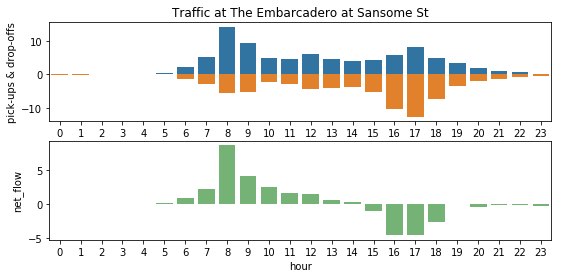

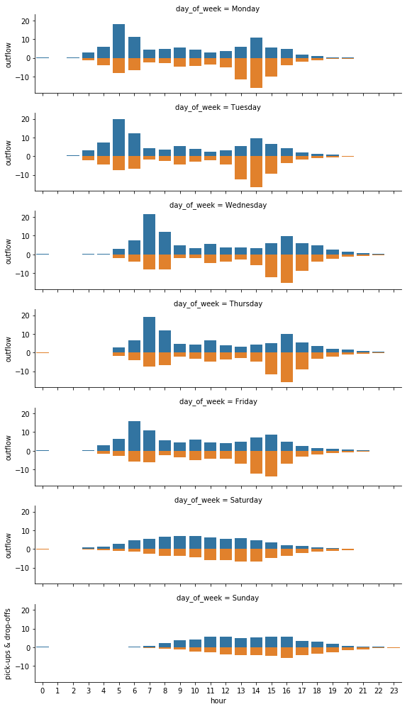

```python
plot_busiest_station_traffic(weekend_traffics, 1)
```

**Station vs. Routes**: Group the dataframe fgb_df_clean by start and end station name, then aggregate and reorganize the data to create a new dataframe with information about routes taken.

```python
def routes(flag):

    mask = fgb_df_clean.weekday == flag
    days = fgb_df_clean.loc[mask,:].date.nunique()

    routes = fgb_df_clean.loc[mask,:].groupby(['start_station_name', 'end_station_name']).size()
    routes = routes.reset_index(name='count')
    routes.sort_values(['count'], ascending=False, inplace=True)
    routes = routes.reset_index(drop=True)

    return routes
```

```python
weekend_routes = routes(0)
weekday_routes = routes(1)
```

```python
weekday_routes.head(10)
```

|  | start_station_name | end_station_name | count |
| --- | --- | --- | --- |
| 0 | San Francisco Ferry Building (Harry Bridges Pl... | The Embarcadero at Sansome St | 4770 |
| 1 | The Embarcadero at Sansome St | Steuart St at Market St | 4251 |
| 2 | Berry St at 4th St | San Francisco Ferry Building (Harry Bridges Pl... | 3898 |
| 3 | Grand Ave at Perkins St | 19th Street BART Station | 3514 |
| 4 | 19th Street BART Station | Grand Ave at Perkins St | 3390 |
| 5 | San Francisco Ferry Building (Harry Bridges Pl... | Berry St at 4th St | 2852 |
| 6 | Bay Pl at Vernon St | 19th Street BART Station | 2768 |
| 7 | Steuart St at Market St | The Embarcadero at Sansome St | 2765 |
| 8 | Market St at 10th St | San Francisco Caltrain Station 2 (Townsend St... | 2664 |
| 9 | The Embarcadero at Sansome St | San Francisco Ferry Building (Harry Bridges Pl... | 2637 |

```python
weekend_routes.head()
```

|  | start_station_name | end_station_name | count |
| --- | --- | --- | --- |
| 0 | San Francisco Ferry Building (Harry Bridges Pl... | The Embarcadero at Sansome St | 1320 |
| 1 | Central Ave at Fell St | Central Ave at Fell St | 691 |
| 2 | The Embarcadero at Sansome St | San Francisco Ferry Building (Harry Bridges Pl... | 606 |
| 3 | The Embarcadero at Sansome St | The Embarcadero at Sansome St | 552 |
| 4 | Market St at 10th St | Powell St BART Station (Market St at 4th St) | 481 |

```python
weekday_traffics = weekday_traffics.sort_values(by='total_traffic_volume', ascending=False).loc[:19,:].reset_index(drop=True)
station = weekday_traffics.station_name[0]

end_station_routes = weekday_routes.groupby('end_station_name').get_group(station)
end_station_routes = end_station_routes.reset_index(drop=True)
```

```python
end_station_routes['count'].sum(), end_station_routes['count'].mean(), end_station_routes.shape[0]
```

```
(44344, 291.7368421052632, 152)
```

### Talk about some of the relationships you observed in this part of the investigation. Were there features that strengthened each other in terms of looking at your feature(s) of interest?

I took a look at the traffics of the busiest station (San Francisco Caltrain Station 2), due to morning/afternoon commutes, there are more activities on weekday than weekend, furthermore, there are more bikes being picked up in the morning and more dropped off in the afternoon, this is typical tidal traffic pattern. However it doesn't give us any information about the pattern on weekends, so I took out the busiest station during weekends, and did the same analysis. On the contrary, more drop-offs in the morning and more pick-ups in the afternoon, without weekday commutes, the tendency is similar but with only one peak for pick-ups and drop-offs separately.

## Store

```python
fgb_df_clean.to_csv('dataset/fordgobike.csv', index=False)
```

```python
station_traffics.to_csv('dataset/station_traffics.csv', index=False)
```

```python
weekday_traffics.to_csv('dataset/weekday_traffics.csv', index=False)
```

```python
weekend_traffics.to_csv('dataset/weekend_traffics.csv', index=False)
```